# Session 4: Designing a geoproject, part 2

Kristof Van Oost, Valentin

Februari 2024

# Today’s program

- Last week’s assignment: discussion
- Advanced geoprocessing: Geoprojects, structure, implementation
- Open Science

# Today’s Learning Objectives

- Developping a geo-spatial model
- Reproducible workflows, sharing your code, Open Science

# Additional resources

- Axolotl [wiki](https://en.wikipedia.org/wiki/Axolotl)
- Biodiversity data [link](https://www.gbif.org/)
- You can have a look to Daniele’s [GitLab repo](https://gitlab.com/danidr/geoprocessing) for some ideas

# 1. Introduction

We are interested in the factors that control the spatial distribution of a given species (habitat and suitability maps) and predict how these will evolve under predicted climate change. Look at the example below from Kraemer et al [2015](https://doi.org/10.7554/eLife.08347) where the dots represent the observed occurrence of mosquito’s in Europe and the color scale represents the suitability (ranging from 1 highly suited to 0 not suitable):

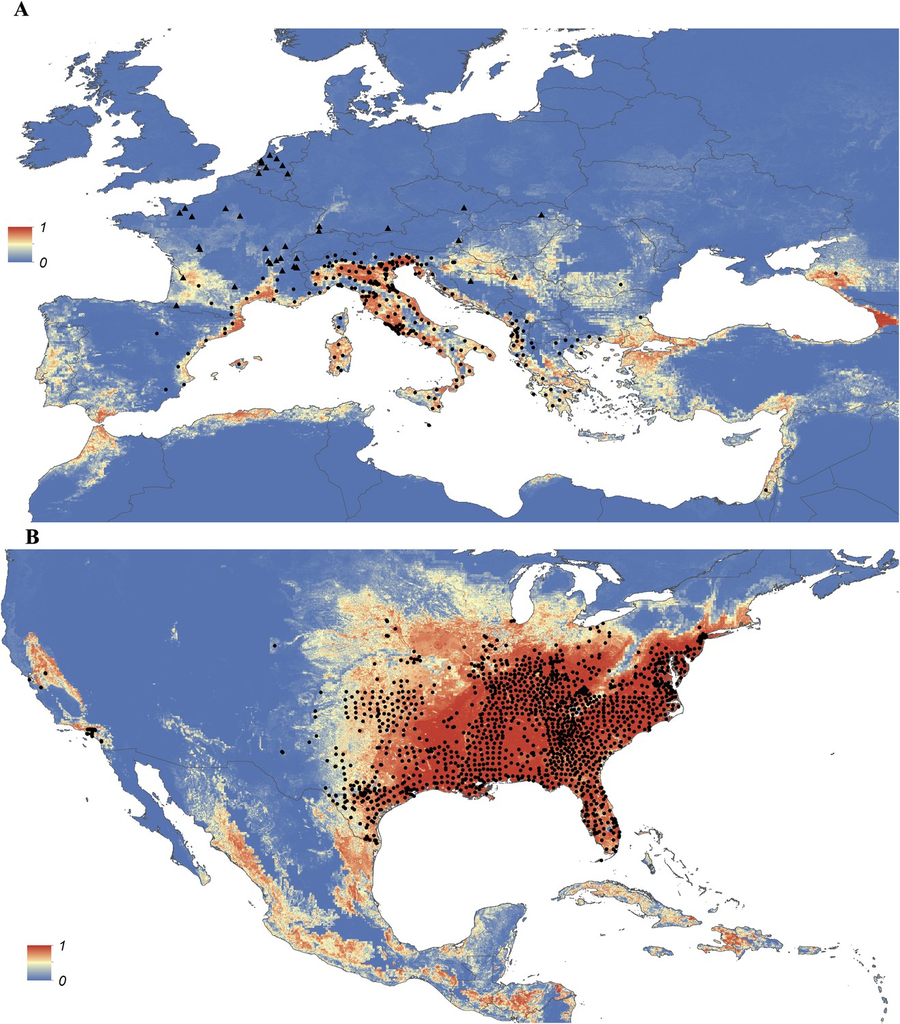

The previous maps are the result of a statistical model where the species presence/absence is modelled as: Species Presence/absence ~ Pred1 + Pred2 + … + Predn

We can construct a logistic model if we have a database with observations and predictor variables. Explore the following dataframa

```r
load("occurence.Rda")
#head(my_train_df)
```

You can explore this dataset as follows:

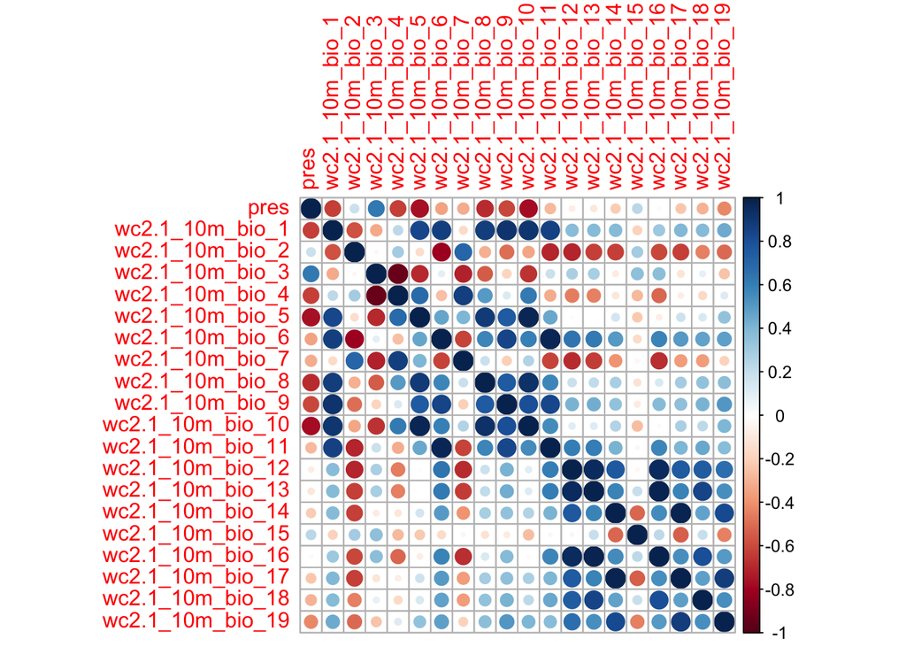

```r
knitr::opts_chunk$set(warning = FALSE, message = FALSE)
#4.a Exploratory analysis
#summary(my_train_df)
correlation<-cor((my_train_df), use="complete.obs") #there are some NA
library(corrplot)
corrplot(correlation)
```

```r
#4.b model
myMod<-glm(pres~ . , data=my_train_df, family = "binomial")
summary(myMod)
```

```
##
## Call:
## glm(formula = pres ~ ., family = "binomial", data = my_train_df)
##
## Coefficients:
##                    Estimate Std. Error    z value Pr(>|z|)
## (Intercept)       8.325e+15  1.960e+08   42470424   <2e-16 ***
## wc2.1_10m_bio_1  -1.121e+15  2.575e+07  -43542172   <2e-16 ***
## wc2.1_10m_bio_2   1.513e+13  1.483e+07    1020506   <2e-16 ***
## wc2.1_10m_bio_3  -8.856e+13  2.884e+06  -30705711   <2e-16 ***
## wc2.1_10m_bio_4  -1.672e+14  1.304e+06 -128284771   <2e-16 ***
## wc2.1_10m_bio_5  -1.752e+20  5.718e+12  -30646295   <2e-16 ***
## wc2.1_10m_bio_6   1.752e+20  5.718e+12   30646140   <2e-16 ***
## wc2.1_10m_bio_7   1.752e+20  5.718e+12   30646269   <2e-16 ***
## wc2.1_10m_bio_8   1.417e+14  3.033e+06   46710338   <2e-16 ***
## wc2.1_10m_bio_9  -1.691e+14  3.336e+06  -50678536   <2e-16 ***
## wc2.1_10m_bio_10  6.804e+15  5.342e+07  127381817   <2e-16 ***
## wc2.1_10m_bio_11 -4.950e+15  6.270e+07  -78953926   <2e-16 ***
## wc2.1_10m_bio_12 -4.471e+12  9.138e+04  -48924142   <2e-16 ***
## wc2.1_10m_bio_13 -5.756e+13  3.531e+05 -163034063   <2e-16 ***
## wc2.1_10m_bio_14 -1.372e+14  2.747e+06  -49940811   <2e-16 ***
## wc2.1_10m_bio_15 -1.395e+13  5.389e+05  -25881933   <2e-16 ***
## wc2.1_10m_bio_16  2.495e+13  1.803e+05  138366193   <2e-16 ***
## wc2.1_10m_bio_17  7.086e+13  1.088e+06   65140743   <2e-16 ***
## wc2.1_10m_bio_18 -3.308e+11  6.719e+04   -4922625   <2e-16 ***
## wc2.1_10m_bio_19 -5.299e+12  2.105e+05  -25177364   <2e-16 ***
## ---
## Signif. codes:  0 '***' 0.001 '**' 0.01 '*' 0.05 '.' 0.1 ' ' 1
##
## (Dispersion parameter for binomial family taken to be 1)
##
##     Null deviance:  701.46  on 505  degrees of freedom
## Residual deviance: 1441.75  on 486  degrees of freedom
## AIC: 1481.7
##
## Number of Fisher Scoring iterations: 23
```

```r
# #check the imporance of the variables: dropterm function removes one-by-one one of the variable and test its imporance in the model selection procedure.
#library(MASS)
#dropterm(myMod, test = "Chisq")
library(modEvA)
Dsquared(myMod, adjust = TRUE) #proportion of deviance explained by a GLM
```

```
## [1] 0.760139
```

If you have spatial data describing the predictors, you could apply the model and create spatial maps. That is what we will do below!

# 2. Objective

The objective of our geoproject is To map the Habitat distribution of a given species, in a given area, In a given temporal moment: current and future climatic conditions. The output should be a change analysis current -> to future (2050 -> 2070 etc)… Something like this

[interactive chart not shown]

Cool! Now let’s break this down and work step by step

# 3. Setting up a workflow

## Summary

A geoproject’s workflow can be summarized as follows:

- Identify a clear goal
- Decompose the framework into small steps:
  - the conceptual aspect
  - the practical aspect : the data I need and the methodology
  - the coding aspect.

As always, consider reproducibility and clear coding ;-) We can conceptualize the project as follows:

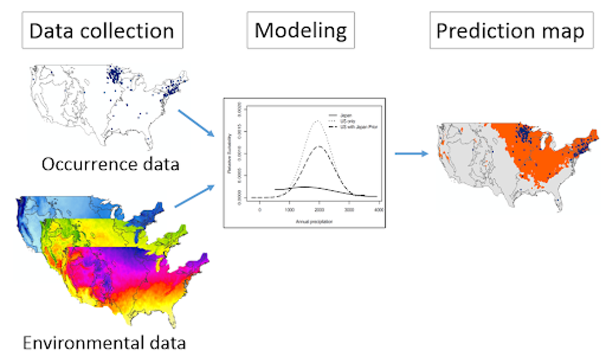

## Define data needs

So what kind of data do we need?

```
+   Species occurrences (GBIF)
+   Species absences: randomly generated
+   Climatic variables (Worldclim) + Vegetation
+   A given species
+   An Area of Interest
```

Create a gemodel which is able to produce as output a species suitability map (in-class, this will be developped here below). Modify your code in order to get predictions for multiple species and/or future scenarios (challenge).

## Visualize the workflow

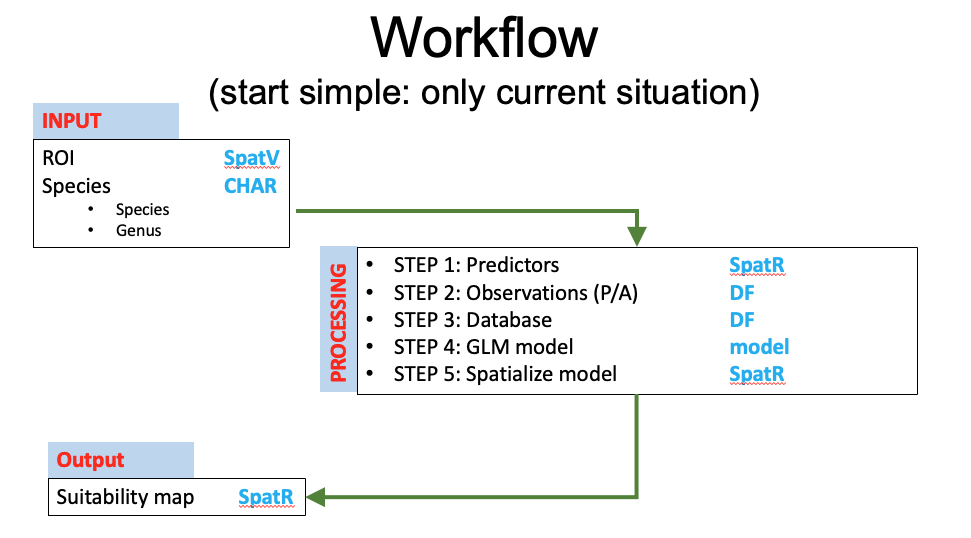

workflow 1

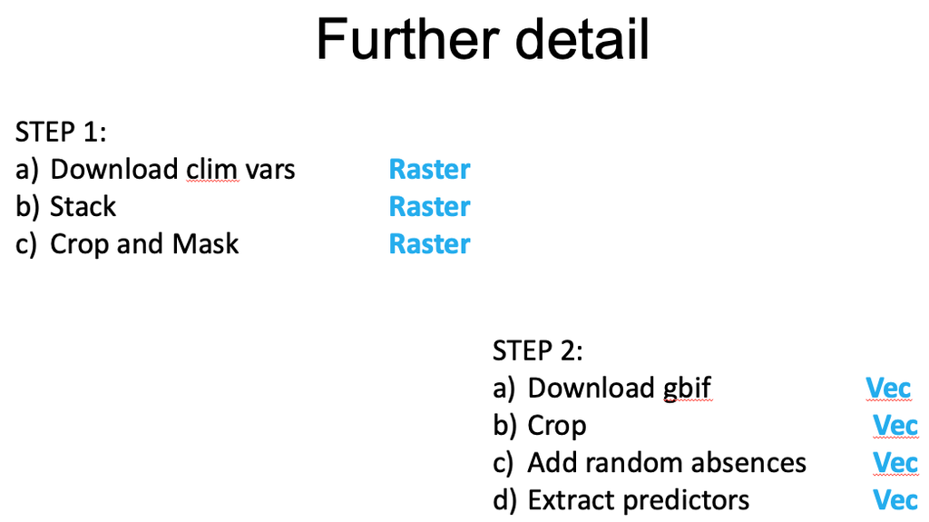

workflow 2

# Coding first steps

At first, let’s try to create a code for a specific example, i.e. without any loops and/or function calls. We try to model for a specific species, the axolotl which can be found in Mexico. Note that we can extract the occurences (sightings) of the axolotl using the `sp_occurrence` function of the `geodata` package. This links to the Global Biodiversity data [see here for more info](https://www.gbif.org/). Make sure you understand the options of the `sp_occurrence` function.

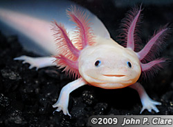

## 0. Environment

```r
#Load libraries
library(geodata)
library(terra)
library(raster)
library(dplyr)
setwd("/Users/kvanoost/Downloads/Session 5")
options(geodata_default_path = "/Users/kvanoost/Documents/UCL/Cours/GIS/geodata")
```

## 1. Load sightings

```r
#Create model for a given region and species:
region <- gadm(country="MEX", level=0, path='GADM')
genus = 'ambystoma'; species = 'mexicanum'

##1. Load sightings data and verification

#1.a Download observations
#library(dismo)
#sightings<-gbif(genus=genus,species = species,ext=sf::st_as_sf(region), sp=TRUE, download = TRUE)
sightings <- sp_occurrence(genus=genus,species = species,ext=(region), sp=TRUE, download = TRUE, geo=TRUE)
sightings <- vect(sightings)
crs(sightings) <- crs(region)
#plot(sightings)

#1.b Check if there're enough observations of the species in ROI
if (length(sightings) < 40) stop("Not enough sightings (ie < 40) of this species in the selected region of interest to model the suitability map. Try another species and/or area of study.")
```

## 2.Load Predictors

Note that we define a resolution, model and scenario for now. We download a long list of potential climatic predictors using the worldclim database, and we use the `bio` variables. See [see here for more info](https://worldclim.org/data/bioclim.html)

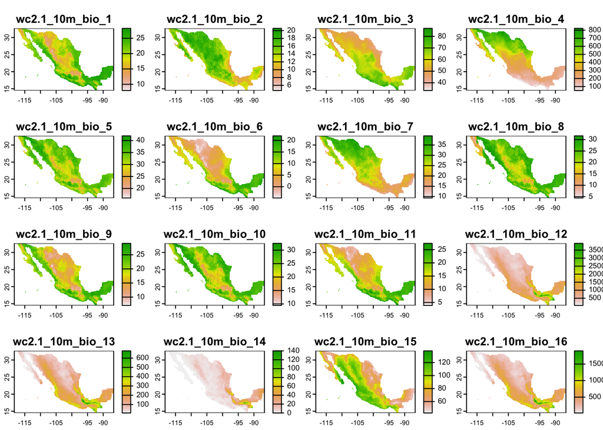

```r
##2. create RasterStack with predictors
res=10;model="ACCESS-CM2";ssp="126"
mybio <- worldclim_global(var='bio', res=res,ssp=ssp) #https://worldclim.org/data/bioclim.html
mybio_aoi <- mybio %>% crop(region) %>% mask(region)
plot(mybio_aoi)
```

## 3. Occurences

```r
##3. Create presence/absence database

sightings$pres<-1

#3.a Generating random absence points
set.seed(1975)
abs <-  spatSample(region,size=length(sightings),method="random")
abs$pres=0

#3.b merge the sightings and absence points
my_occ_df=sightings+abs
# quickly visualize this
library(leaflet)
leaflet((my_occ_df)) %>% addTiles() %>%
  addCircleMarkers(
    color = ~ifelse(pres == 0,"red", "blue"),
    radius = 1
  )
```

[interactive chart not shown]

```r
#3.c Extract bio variables (from mybio_aio) values for each observation
my_train_df<-terra::extract(mybio_aoi,my_occ_df,df=TRUE,bind=TRUE)
my_train_df <- as.data.frame(my_train_df)
my_train_df <- my_train_df %>% dplyr::select(pres, starts_with("wc"))
```

## 4. Logistic Model

```r
##4. Modelling
#4.a Exploratory analysis
# summary(my_train_df)
# correlation<-cor((my_train_df), use="complete.obs") #there are some NA
# library(corrplot)
# corrplot(correlation)

#4.b model
myMod<-glm(pres~ . , data=my_train_df, family = "binomial")
# summary(myMod)
# #check the imporance of the variables: dropterm function removes one-by-one one of the variable and test its imporance in the model selection procedure.
# # library(MASS)
# # dropterm(myMod, test = "Chisq")
library(modEvA)
Dsquared(myMod, adjust = TRUE) #proportion of deviance explained by a GLM
```

```
## [1] 0.760139
```

## 5. Apply spatial model

```r
#5.b Creating suitability layers
  Pred<-predict(mybio_aoi,myMod,type='response')   ### Rastermap
```

## 6. Create a map

And finally, visualize the map

```r
#6 Create map
  # you can blank the regions below a treshold
  Pred <- ifel(Pred < 0.01, NA, Pred)
  library(mapview)
  map <- mapview(Pred, col.regions="red", na.color = "transparent",layer.name='Suitability',legend=FALSE) +   mapview(subset(my_occ_df,my_occ_df$pres==1),cex=2,popup=FALSE,layer.name='Observations')
  map
```

[interactive chart not shown]

# Generalizing the code

Now that it works for one example, we can now create a function which basically is a copy paste of the above, but where we add variables for the parameters. Note the use of a `list` as the output contains the output in spatRaster format, the model performance as well as maps. A list a very usefull when combining different types of data. Note that naming the list items helps to reference the items more easily aftwards (see below).

```r
#### Wrap this in a function
  Presentday_suitability_map_fct<-function(region,genus,species,res){
    ###Description: Function to model the suitability (present and future) of an area for a species.
    ###Inputs:
    ##region of interest (spatVector) could be a country with ISO code ,
    ##genus and species of interset (see https://www.gbif.org/)
    ##res (numeric): resolution 2.5 5 or 10,
    ###Output: 1 suitability map as a map, a spatRaster suitability map, metric for model performance (Dsquared)

    ##1. Load sightings data and verification

    #1.a Download observations
    sightings <- sp_occurrence(genus=genus,species = species,ext=(region), sp=TRUE, download = TRUE, geo=TRUE)
    sightings <- vect(sightings)
    crs(sightings) <- crs(region)

    #1.b Check if there're enough observations of the species in ROI
    if (length(sightings) < 40) stop("Not enough sightings (ie < 40) of this species in the selected region of interest to model the suitability map. Try another species and/or area of study.")


    ##2. create RasterStack with predictors
    mybio <- worldclim_global(var='bio', res=res,ssp=ssp) #https://worldclim.org/data/bioclim.html
    mybio_aoi <- mybio %>% crop(region) %>% mask(region)
    #plot(mybio_aoi)

    ##3. Create presence/abscence database

    sightings$pres<-1

    #3.a Generating random absence points
    set.seed(1975)
    abs <-  spatSample(region,size=length(sightings),method="random")
    abs$pres=0

    #3.b merge the sightings and absence points
    my_occ_df=sightings+abs

    #3.c Extract bio variables (from mybio_aio) values for each observation
    my_train_df<-terra::extract(mybio_aoi,my_occ_df,df=TRUE,bind=TRUE)
    my_train_df <- as.data.frame(my_train_df)
    my_train_df <- my_train_df %>% dplyr::select(pres, starts_with("wc"))

    ##4. Modelling
    #4.a Exploratory analysis
    # summary(my_train_df)
    # correlation<-cor(my_train_df, use="complete.obs") #there are some NA
    # library(corrplot)
    # corrplot(correlation)

    #4.b model
    myMod<-glm(pres~ . , data=my_train_df, family = "binomial")
    # summary(myMod)
    # #check the imporance of the variables: dropterm function removes one-by-one one of the variable and test its imporance in the model selection procedure.
    # # library(MASS)
    # # dropterm(myMod, test = "Chisq")
     library(modEvA)
     Dsq <- Dsquared(myMod, adjust = TRUE)


    #5.b Creating suitability layers
    Pred<-predict(mybio_aoi,myMod,type='response')   ### Rastermap

    #6 Create map
   # map <- mapview(Pred, col.regions="red", na.color = "transparent",layer.name='Suitability',legend=FALSE) + mapview(subset(my_occ_df,my_occ_df$pres==1),cex=2,popup=FALSE,layer.name='Observations')
    pal <- colorNumeric(c("#FFFFCC", "#41B6C4","#0C2C84" ), domain = c(0,1),
                        na.color = "transparent")
    map<-leaflet::leaflet() %>% leaflet::addTiles() %>%
      leaflet::addRasterImage(raster(Pred), colors = pal, opacity = 0.8) %>%
      leaflet::addLegend(pal = pal, values = raster::values(Pred),
                         title = paste("Suitability"))
    results<-(list(map,Pred, Dsq))
    names(results) <- c('suitability_leafletmap','suitability_raster','Dsq')
    return(results)


  }
```

We can now test this function:

```r
# test function
  a <- Presentday_suitability_map_fct(gadm(country="MEX", level=0, path='GADM'),genus='ambystoma',species = 'mexicanum',res=10)
```

Explore what is contained in the variable,`note that you can also use`a$`

```r
a
```

```
## $suitability_leafletmap
##
## $suitability_raster
## class       : SpatRaster
## dimensions  : 109, 190, 1  (nrow, ncol, nlyr)
## resolution  : 0.1666667, 0.1666667  (x, y)
## extent      : -118.3333, -86.66667, 14.5, 32.66667  (xmin, xmax, ymin, ymax)
## coord. ref. : lon/lat WGS 84 (EPSG:4326)
## source(s)   : memory
## name        :         lyr1
## min value   : 2.220446e-16
## max value   : 1.000000e+00
##
## $Dsq
## [1] 0.760139
```

```r
a$suitability_leafletmap
```

[interactive chart not shown]

You can find a copy of the full code in one single chunck below.

# Challenge

Building on what we have done there toghether, the challenge is now to further develop this geomodel and to make it broader by also predicting future suitability maps using the cmip climate predictions. Make sure that your model can predict current suitability and suitability for 2030, 2050 and 2070. For example using a loop over the years:

> `years<-c("1970-2000","2021-2040", "2041-2060", "2061-2080")`

Also make sure your model can handle different models and scenario’s.

The output should be a list containing leaflet maps for the current situation, leaflet maps showing the change for each interval relative to the current condition, and the suitability maps for each time interval in spatRaster format. Some tips:

You can store your results as a list, and add them to another list (usual when looping)

> *. `my_list[[j]] <- output # Store output, which is a list, in another list`* . `list(result[[1]][[2]] # you can acces a list in a list using the double square brackets`

It is good practice to name your items in the list, for example:

> *. `maps_change <- list(map_change30,map_change50,map_change70)` `names(maps_change) <- c('changemap_2030','changemap_2050','changemap_2070')`

Have fun!!

# The full code

```r
library("terra")
library(geodata)

setwd("/Users/kvanoost/Downloads/Session 5")

#Create model for a given region and species:
region <- gadm(country="MEX", level=0, path='GADM')
genus = 'ambystoma'; species = 'mexicanum'

##1. Load sightings data and verification

#1.a Download observations
#library(dismo)
#sightings<-gbif(genus=genus,species = species,ext=sf::st_as_sf(region), sp=TRUE, download = TRUE)
sightings <- sp_occurrence(genus=genus,species = species,ext=(region), sp=TRUE, download = TRUE, geo=TRUE)
sightings <- vect(sightings)
crs(sightings) <- crs(region)
#plot(sightings)

#1.b Check if there're enough observations of the species in ROI
if (length(sightings) < 40) stop("Not enough sightings (ie < 40) of this species in the selected region of interest to model the suitability map. Try another species and/or area of study.")


##2. create RasterStack with predictors
res=10;model="ACCESS-CM2";ssp="126"
mybio <- worldclim_global(var='bio', res=res,ssp=ssp) #https://worldclim.org/data/bioclim.html
mybio_aoi <- mybio %>% crop(region) %>% mask(region)
#plot(mybio_aoi)

##3. Create presence/abscence database

sightings$pres<-1

#3.a Generating random absence points
set.seed(1975)
abs <-  spatSample(region,size=length(sightings),method="random")
abs$pres=0

#3.b merge the sightings and absence points
my_occ_df=sightings+abs

#3.c Extract bio variables (from mybio_aio) values for each observation
my_train_df<-terra::extract(mybio_aoi,my_occ_df,df=TRUE,bind=TRUE)
my_train_df <- as.data.frame(my_train_df)
my_train_df <- my_train_df %>% dplyr::select(pres, starts_with("wc"))

library(leaflet)
#leaflet((my_occ_df)) %>% addTiles() %>%
#  addCircleMarkers(
#    color = ~ifelse(pres == 0,"red", "blue"),
#    radius = 1
#  )


##4. Modelling
#4.a Exploratory analysis
# summary(my_train_df)
# correlation<-cor((my_train_df), use="complete.obs") #there are some NA
# library(corrplot)
# corrplot(correlation)

#4.b model
myMod<-glm(pres~ . , data=my_train_df, family = "binomial")
# summary(myMod)
# #check the imporance of the variables: dropterm function removes one-by-one one of the variable and test its imporance in the model selection procedure.
# # library(MASS)
# # dropterm(myMod, test = "Chisq")
# library(modEvA)
# Dsquared(myMod, adjust = TRUE) #proportion of deviance explained by a GLM


#5.b Creating suitability layers
  Pred<-predict(mybio_aoi,myMod,type='response')   ### Rastermap

#6 Create map
  # you can blank the regions below a treshold
  Pred <- ifel(Pred < 0.01, NA, Pred)
  map <- mapview(Pred, col.regions="red", na.color = "transparent",layer.name='Suitability',legend=FALSE) + mapview(subset(my_occ_df,my_occ_df$pres==1),cex=2,popup=FALSE,layer.name='Observations')
 # map


###################@

#### Wrap this in a function
  Presentday_suitability_map_fct<-function(region,genus,species,res){
    ###Description: Function to model the suitability (present and future) of an area for a species.
    ###Inputs:
    ##region of interest (spatVector) could be a country with ISO code ,
    ##genus and species of interset (see https://www.gbif.org/)
    ##res (numeric): resolution 2.5 5 or 10,
    ###Output: 1 suitability map as a map, a spatRaster suitability map, metric for model performance (Dsquared)

    ##1. Load sightings data and verification

    #1.a Download observations
    sightings <- sp_occurrence(genus=genus,species = species,ext=(region), sp=TRUE, download = TRUE, geo=TRUE)
    sightings <- vect(sightings)
    crs(sightings) <- crs(region)

    #1.b Check if there're enough observations of the species in ROI
    if (length(sightings) < 40) stop("Not enough sightings (ie < 40) of this species in the selected region of interest to model the suitability map. Try another species and/or area of study.")


    ##2. create RasterStack with predictors
    mybio <- worldclim_global(var='bio', res=res,ssp=ssp) #https://worldclim.org/data/bioclim.html
    mybio_aoi <- mybio %>% crop(region) %>% mask(region)
    plot(mybio_aoi)

    ##3. Create presence/abscence database

    sightings$pres<-1

    #3.a Generating random absence points
    set.seed(1975)
    abs <-  spatSample(region,size=length(sightings),method="random")
    abs$pres=0

    #3.b merge the sightings and absence points
    my_occ_df=sightings+abs

    #3.c Extract bio variables (from mybio_aio) values for each observation
    my_train_df<-terra::extract(mybio_aoi,my_occ_df,df=TRUE,bind=TRUE)
    my_train_df <- as.data.frame(my_train_df)
    my_train_df <- my_train_df %>% dplyr::select(pres, starts_with("wc"))

    ##4. Modelling
    #4.a Exploratory analysis
    # summary(my_train_df)
    # correlation<-cor(my_train_df, use="complete.obs") #there are some NA
    # library(corrplot)
    # corrplot(correlation)

    #4.b model
    myMod<-glm(pres~ . , data=my_train_df, family = "binomial")
    # summary(myMod)
    # #check the imporance of the variables: dropterm function removes one-by-one one of the variable and test its imporance in the model selection procedure.
    # # library(MASS)
    # # dropterm(myMod, test = "Chisq")
     library(modEvA)
     Dsq <- Dsquared(myMod, adjust = TRUE)


    #5.b Creating suitability layers
    Pred<-predict(mybio_aoi,myMod,type='response')   ### Rastermap

    #6 Create map
    # you can blank the regions below a treshold
    #Pred <- ifel(Pred < 0.01, NA, Pred)
    #map <- mapview(Pred, col.regions="red", na.color = "transparent",layer.name='Suitability',legend=FALSE) + mapview(subset(my_occ_df,my_occ_df$pres==1),cex=2,popup=FALSE,layer.name='Observations')
    pal <- colorNumeric(c("#FFFFCC", "#41B6C4","#0C2C84" ), domain = c(0,1),
                        na.color = "transparent")
    map<-leaflet::leaflet() %>% leaflet::addTiles() %>%
      leaflet::addRasterImage(raster(Pred), colors = pal, opacity = 0.8) %>%
      leaflet::addLegend(pal = pal, values = raster::values(Pred),
                         title = paste("Suitability"))
    results<-(list(map,Pred, Dsq))
    names(results) <- c('suitability_leafletmap','suitability_raster','Dsq')
    return(results)


  }

# test function
  a <- Presentday_suitability_map_fct(gadm(country="MEX", level=0, path='GADM'),genus='ambystoma',species = 'mexicanum',res=10)
```